# BIOENV ANALYSIS

Azeez Olalekan, Baki

2022-04-13

# Understanding the Effects of Environmental and Biological Parameters on Bay of Biscay.

An oceanographic campaign was carried out on the continental shelf of the Bay of Biscay. The dataset (BIOENV) is composed of biological and environmental descriptors measured on the seabed at 30 sampling stations. Biological variables consist of abundance data associated with five benthic species (labelled from sp1 to sp5). Environmental variables are water depth (in meters), a pollution index (the higher the index, the higher the level of pollution), temperature (in °C) and the nature of sediment (three categories: C for clay/silt, S for sand and G for gravel/stone). Objectives were (1) to analyze the relationships between environmental and biological variables, and (2) to characterize the relationships between environmental gradients and benthic community distribution.

```r
library(dplyr)
bioenv <- read.delim("BIOENV.txt", header = T)
glimpse(bioenv)
```

```
## Rows: 30
## Columns: 10
## $ X           <chr> "s1 ", "s2 ", "s3 ", "s4 ", "s5 ", "s6 ", "s7 ", "s8 ", "s~
## $ sp1         <int> 0, 26, 0, 0, 13, 31, 9, 2, 17, 0, 0, 14, 0, 13, 4, 42, 4, ~
## $ sp2         <int> 2, 4, 10, 0, 5, 21, 6, 0, 7, 5, 8, 11, 0, 0, 0, 20, 0, 15,~
## $ sp3         <int> 9, 13, 9, 15, 3, 13, 0, 0, 10, 26, 8, 13, 19, 0, 10, 0, 0,~
## $ sp4         <int> 14, 11, 8, 3, 10, 16, 11, 0, 14, 9, 6, 15, 0, 9, 12, 3, 0,~
## $ sp5         <int> 2, 0, 0, 0, 7, 5, 2, 1, 6, 0, 7, 0, 6, 0, 0, 6, 0, 0, 3, 0~
## $ Pollution   <dbl> 4.8, 2.8, 5.4, 8.2, 3.9, 2.6, 4.6, 5.1, 3.9, 7.0, 6.5, 3.8~
## $ Depth       <int> 72, 75, 59, 64, 61, 94, 53, 61, 68, 69, 57, 84, 53, 83, 10~
## $ Temperature <dbl> 3.5, 2.5, 2.7, 2.9, 3.1, 3.5, 2.9, 3.3, 3.4, 3.0, 3.3, 3.1~
## $ Sediment    <chr> "S", "C", "C", "S", "C", "G", "S", "C", "C", "S", "C", "S"~
```

## Scatterplot to show relationship between the Quantitative variables.

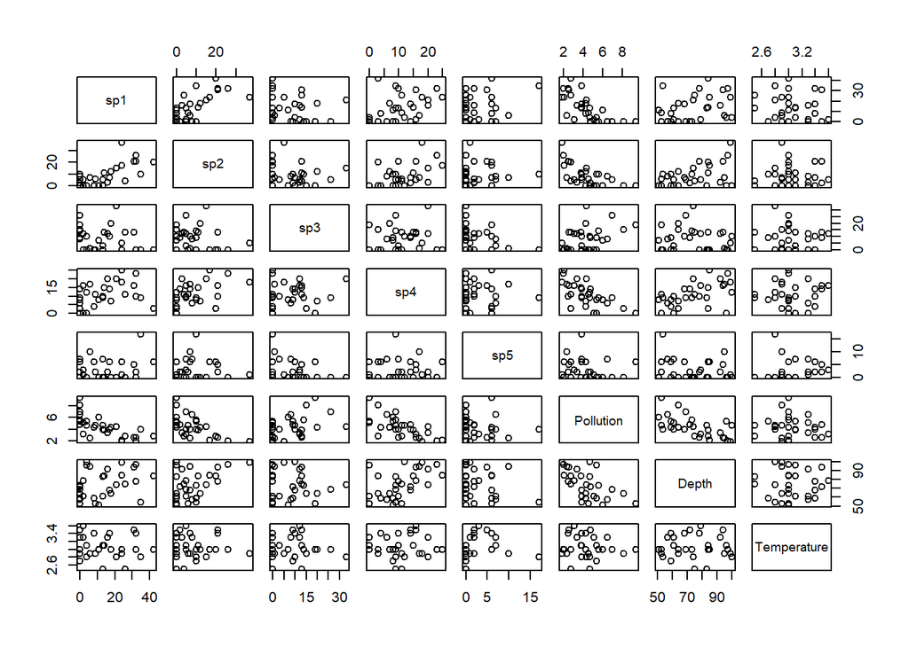

```r
knitr::opts_chunk$set(echo = TRUE)
pairs(bioenv[,-c(1,10)])
```

We observed relationship between some of the biological parameters and environmental variables. E.g sp4 and Depth.

## Boxplot showing the distribution of sediment according to the Depth

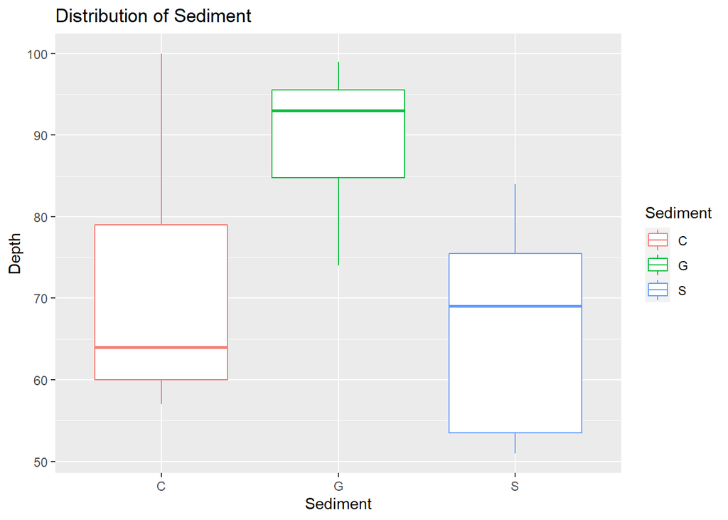

```r
knitr::opts_chunk$set(echo = TRUE)
library(ggplot2)
boxplot <- ggplot(data=bioenv, mapping = aes(x= Sediment, y=Depth, col=Sediment))+
  geom_boxplot()+
  ggtitle("Distribution of Sediment")
boxplot
```

##Summary Statistics

```r
summary <- bioenv %>%
  group_by(Sediment) %>%
  summarise(avg_pollution = mean(Pollution),
            avg_temp = mean(Temperature),
            avg_depth = mean(Depth)) %>%
  arrange(desc(avg_pollution))
summary
```

```
## # A tibble: 3 x 4
##   Sediment avg_pollution avg_temp avg_depth
##   <chr>            <dbl>    <dbl>     <dbl>
## 1 S                 5.35     3.11      66.4
## 2 C                 4.64     3.01      71.2
## 3 G                 2.7      3.05      90
```

#Correlation

```
##                    sp1         sp2         sp3          sp4          sp5
## sp1          1.0000000  0.67339954 -0.23992888  0.358192050  0.273522301
## sp2          0.6733995  1.00000000 -0.08041947  0.501834036  0.036914702
## sp3         -0.2399289 -0.08041947  1.00000000  0.081504483 -0.343540453
## sp4          0.3581921  0.50183404  0.08150448  1.000000000 -0.004048517
## sp5          0.2735223  0.03691470 -0.34354045 -0.004048517  1.000000000
## Pollution   -0.6918290 -0.61508990  0.40414667 -0.661010315 -0.154839983
## Depth        0.3083088  0.42606270 -0.11997791  0.523494288 -0.211615073
## Temperature -0.1005225  0.01011175 -0.06258780  0.038074068  0.150343050
##              Pollution        Depth  Temperature
## sp1         -0.6918290  0.308308815 -0.100522460
## sp2         -0.6150899  0.426062700  0.010111750
## sp3          0.4041467 -0.119977915 -0.062587799
## sp4         -0.6610103  0.523494288  0.038074068
## sp5         -0.1548400 -0.211615073  0.150343050
## Pollution    1.0000000 -0.587949691 -0.100606908
## Depth       -0.5879497  1.000000000 -0.003428729
## Temperature -0.1006069 -0.003428729  1.000000000
```

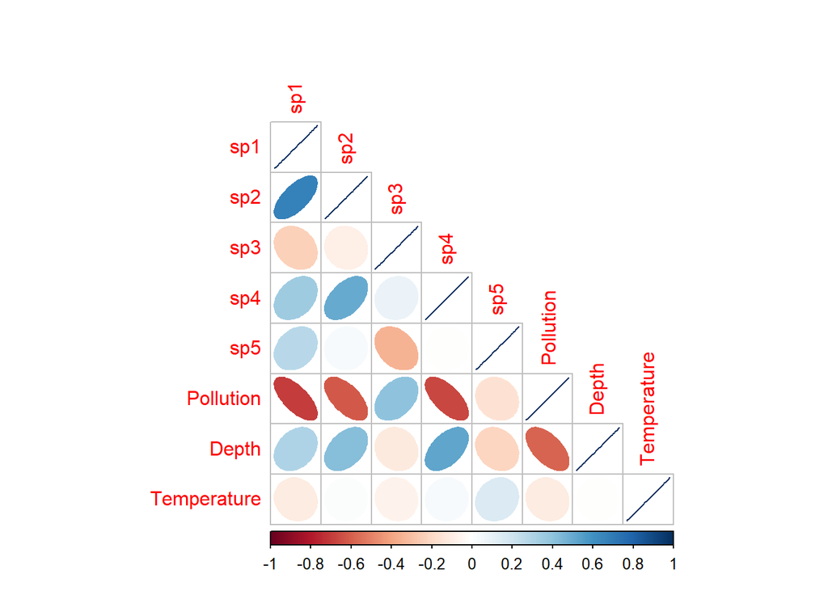

# Question 1 (6 points) : Does the nature of the sediment vary with the water depth at the level of significance  = 1%?

```r
bioenv$Sf <- as.factor(bioenv$Sediment)
head(bioenv)
```

```
##     X sp1 sp2 sp3 sp4 sp5 Pollution Depth Temperature Sediment Sf
## 1 s1    0   2   9  14   2       4.8    72         3.5        S  S
## 2 s2   26   4  13  11   0       2.8    75         2.5        C  C
## 3 s3    0  10   9   8   0       5.4    59         2.7        C  C
## 4 s4    0   0  15   3   0       8.2    64         2.9        S  S
## 5 s5   13   5   3  10   7       3.9    61         3.1        C  C
## 6 s6   31  21  13  16   5       2.6    94         3.5        G  G
```

## One-way Anova

```r
bioenv_aov <- aov(Depth~Sf, data=bioenv)
anova(bioenv_aov)
```

```
## Analysis of Variance Table
##
## Response: Depth
##           Df Sum Sq Mean Sq F value   Pr(>F)
## Sf         2 2771.2 1385.59  8.6999 0.001213 **
## Residuals 27 4300.2  159.27
## ---
## Signif. codes:  0 '***' 0.001 '**' 0.01 '*' 0.05 '.' 0.1 ' ' 1
```

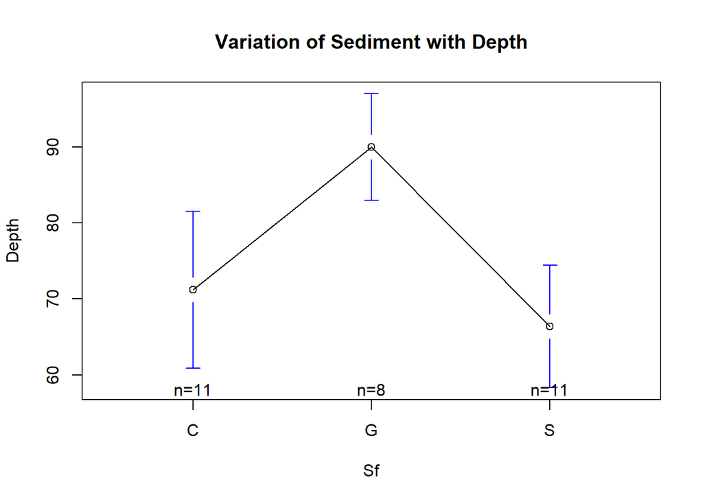

```r
#install.packages("gplot")
library(gplots)
plotmeans(Depth~Sf, data=bioenv,
          main = "Variation of Sediment with Depth")
```

```r
diff <- TukeyHSD(bioenv_aov, conf.level = .99)
diff
```

```
##   Tukey multiple comparisons of means
##     99% family-wise confidence level
##
## Fit: aov(formula = Depth ~ Sf, data = bioenv)
##
## $Sf
##           diff        lwr       upr     p adj
## G-C  18.818182   0.180305 37.456059 0.0092780
## S-C  -4.818182 -21.921471 12.285107 0.6478039
## S-G -23.636364 -42.274240 -4.998487 0.0011511
```

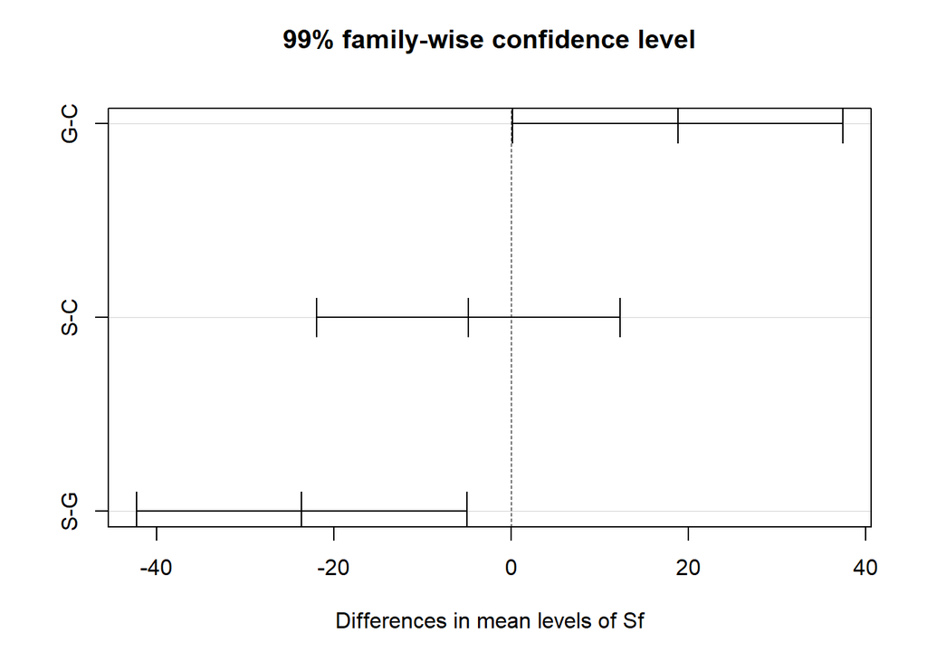

```r
plot(diff)
```

# Question 2 (6 points) : Does the level of pollution impact the total abundance of species at the level of significance  = 1% ?

```r
bioenv <- bioenv %>%
  mutate(total_species = (sp1+sp2+sp3+sp4+sp5))
head(bioenv)
```

```
##     X sp1 sp2 sp3 sp4 sp5 Pollution Depth Temperature Sediment Sf total_species
## 1 s1    0   2   9  14   2       4.8    72         3.5        S  S            27
## 2 s2   26   4  13  11   0       2.8    75         2.5        C  C            54
## 3 s3    0  10   9   8   0       5.4    59         2.7        C  C            27
## 4 s4    0   0  15   3   0       8.2    64         2.9        S  S            18
## 5 s5   13   5   3  10   7       3.9    61         3.1        C  C            38
## 6 s6   31  21  13  16   5       2.6    94         3.5        G  G            86
```

```r
bioenv_reg <- lm(total_species~Pollution,
                 data= bioenv)
summary(bioenv_reg)
```

```
##
## Call:
## lm(formula = total_species ~ Pollution, data = bioenv)
##
## Residuals:
##     Min      1Q  Median      3Q     Max
## -35.173 -14.375   1.509  12.423  44.680
##
## Coefficients:
##             Estimate Std. Error t value Pr(>|t|)
## (Intercept)   82.958      9.263   8.956 1.04e-09 ***
## Pollution     -8.781      1.959  -4.483 0.000114 ***
## ---
## Signif. codes:  0 '***' 0.001 '**' 0.01 '*' 0.05 '.' 0.1 ' ' 1
##
## Residual standard error: 19.05 on 28 degrees of freedom
## Multiple R-squared:  0.4179, Adjusted R-squared:  0.3971
## F-statistic:  20.1 on 1 and 28 DF,  p-value: 0.0001137
```

Obs: The result shows that pollution has significant impact on the total abundant of the species at 0.99 CI (p<0.05). The adjusted R-squared shows that the pollution predicted 39% of the variation in the abundance of the species.

# Question 3 (8 points) : From a principal component analysis carried out on all the quantitative variables, describe the relationships between the different variables as well as the relationships between environmental gradients and observations / stations.

```
## Importance of components:
##                            PC1     PC2    PC3     PC4     PC5     PC6     PC7
## Standard deviation     18.2472 12.0743 8.6941 5.66329 4.95808 3.21755 0.77592
## Proportion of Variance  0.5353  0.2344 0.1215 0.05156 0.03952 0.01664 0.00097
## Cumulative Proportion   0.5353  0.7697 0.8912 0.94276 0.98228 0.99892 0.99989
##                            PC8
## Standard deviation     0.26087
## Proportion of Variance 0.00011
## Cumulative Proportion  1.00000
```

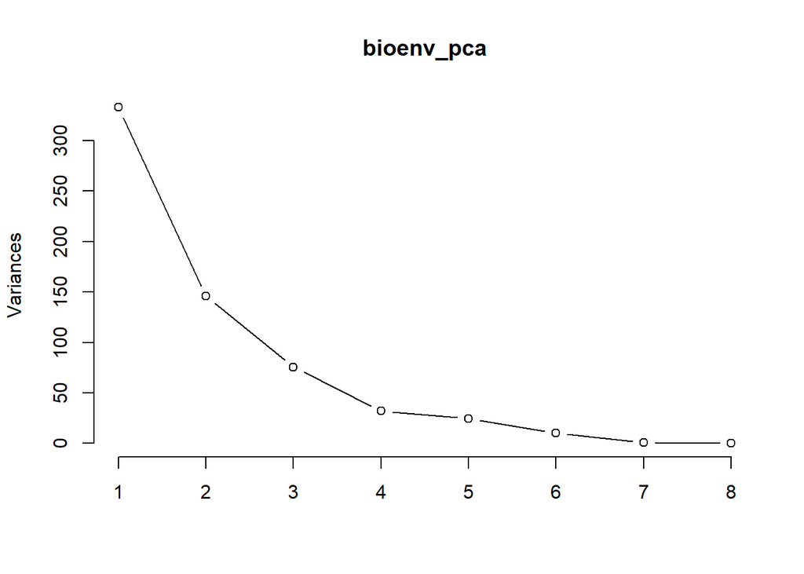

```
##                       PC1          PC2         PC3          PC4          PC5
## sp1          0.4813809691  0.702904589 -0.04880708 -0.499320741 -0.070432998
## sp2          0.3660391603  0.288768400 -0.28053063  0.694998094  0.455181216
## sp3         -0.1009832473 -0.172133536 -0.90902715 -0.308607611  0.057551701
## sp4          0.2312241357 -0.036122492 -0.24367526  0.372389881 -0.834809044
## sp5         -0.0048948373  0.153166651  0.13500940  0.005388007 -0.260482084
## Pollution   -0.0794201768 -0.034182013 -0.03115947 -0.040058683  0.101700333
## Depth        0.7511949039 -0.605783102  0.11836353 -0.178987230  0.097087152
## Temperature -0.0004135705 -0.001249413  0.00201778  0.008567921 -0.003335762
##                     PC6          PC7          PC8
## sp1         -0.12032574  0.053831839 -0.012538292
## sp2          0.11687166  0.006204308  0.004576308
## sp3          0.17418050 -0.070170231  0.005339489
## sp4         -0.18899012  0.120264141 -0.009583372
## sp5          0.94338624 -0.012000381  0.016938706
## Pollution    0.05218951  0.983427173 -0.098755803
## Depth        0.11341977  0.019868629 -0.001405794
## Temperature  0.01553151 -0.100042688 -0.994816512
```

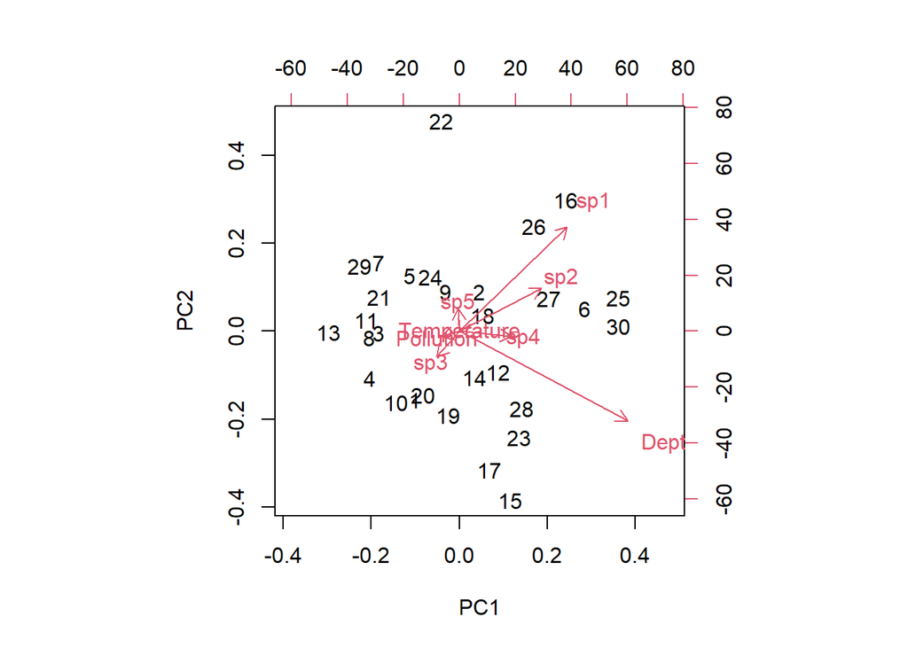

Obs: The pca results revealed that PC1 and PC2 captured high proportions of the variance, with a cumulative of 76.9%. From the biplot, Depth has high relationship with PC1 and negative relationship with PC2. Also sp1 has high relationship with PC2. sp1, sp2 and Depth has positive relationship in PC1.